# tutorial3

# Question 1

## (a)

$$\begin{align*}
F_X(x) &= \int_{-\infty}^x f_X(t) dt\\
&= \int_{0}^x 2 e^{-2t} dt\\
&= - e^{-2t} \,\Big\vert_0^x\\
&= 1 - e^{-2x} \,.
\end{align*}$$

Notice that I use $t$ as the dummy variable inside the integral because $x$ is used as the upper limit in the definite integral.

## (b)

Note: $-x e^{-2x} \,\Big\vert_0^\infty$ evaluates to 0, where l’Hopital’s rule is used implicitly:

$$\begin{align*}
& \, \,\lim_{c \rightarrow \infty} x e^{-2x}\\
&= \lim_{c \rightarrow \infty} \frac{x}{e^{2x}} \text{
indeterminate form of a quotient of the form} \frac{\infty}{\infty}\\
&= \lim_{c \rightarrow \infty} \frac{1}{2e^{2x}}\\
&= 0 \,.
\end{align*}$$

## (c)

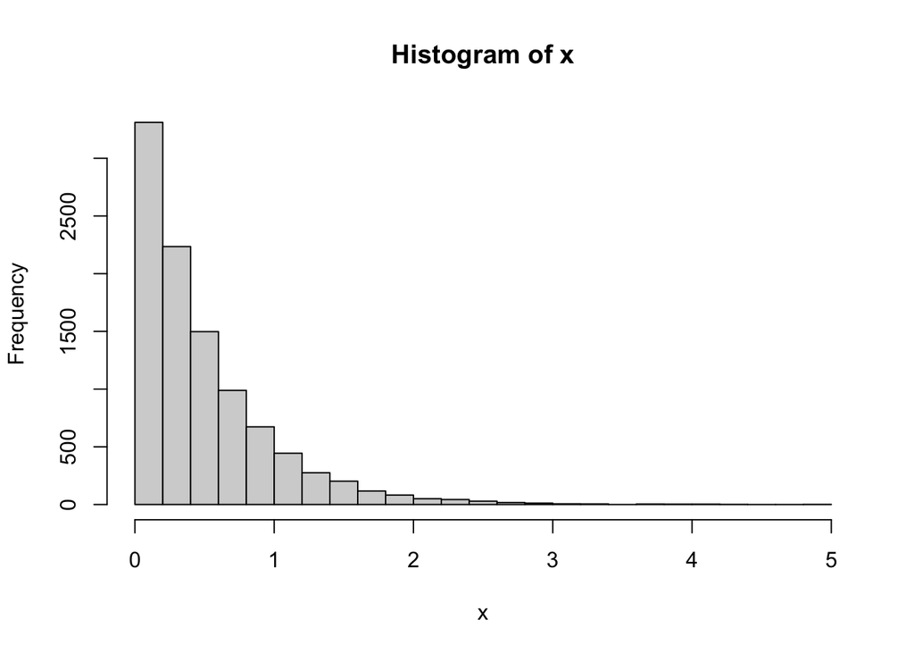

```r
set.seed(123)
u <- runif(10000, 0, 1)
x <- -0.5*log(1 - u)

hist(x, breaks=30)
```

To verify that our samples in the vector `x` are indeed drawn from $f_X(x)$, we can plot the latter distribution over the histogram. Note: notice the `prob=TRUE` argument in hist that renders turns the histogram into an approximate density.

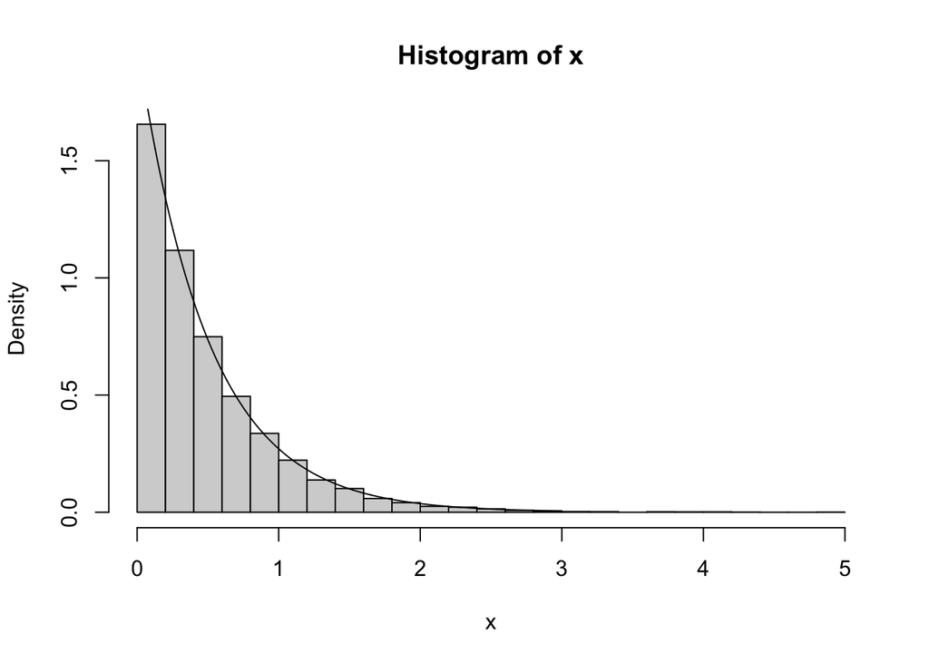

```r
pdf <- function(z){
  return (2*exp(-2*z))
}

z <- seq(0, 3, by=0.001)

hist(x, breaks=30, prob=TRUE)
lines(z, pdf(z))
```

## (d)

```r
mean(x)
```

```
## [1] 0.4931364
```

# Question 2

## (a)

Solve for $\int_0^2 f_Y(y) dy = 1$:
$$\begin{align*}
&\,\,\int_0^2 f_Y(y) dy\\
&= \int_0^2 c(2 - y) dy\\
&= c\left(2y - \frac{y^2}{2} \right)\, \Bigg\vert^2_0\\
&= 2c \, ,
\end{align*}$$
which implies that $c = \frac{1}{2}$.

## (b)

Using evidence from part **(a)** above, $\int f_Y(y) dy = y - \frac{y^2}{4}$. Now, we add the appropriate intervals for $y$ since $F_Y(y)$ needs to be written as a piecewise function.

$$\begin{align*}
F_y(y) = \begin{cases}
0 &\qquad \text{if } y < 0\\
y - \frac{y^2}{4} &\qquad \text{if } 0 \leq y \leq 2\\
1 &\qquad \text{if } y > 2 \, .
\end{cases}
\end{align*}$$

## (c)

Notice that $P(1 < Y \leq 2) = P(Y \leq 2) - P(Y \leq 1) = 1 - P(Y \leq 1)$. Since we have the CDF from part **(b)**, we have that:
$$\begin{align*}
P(1 < Y \leq 2) = 1 - P(Y \leq 1) = 1 - \left(1 -
\frac{1}{4}\right) = \frac{1}{4} \, .
\end{align*}$$